# STAT184 Project

Xuanting Dong & Zhixuan Yang

12/9/2019

### Research Question

#### Which factors can heavily influence the sales of video games.

#### Here we first change all the column names to lower case, which is more reader friendly.

```r
# clean up workspace environment
rm(list = ls())

# all packages used for the assignment
library(tidyverse)
library(DataComputing)
library(party)
```

```r
library(dplyr)
library(rpart)
library(rpart.plot)
library(readr)

# user defined functions

#function to read file
file <- function(url){
  file <- read_csv(url)
  return (file)
}

#function to rename the attributes to lower-case
rename_primary <- function(data){
  data <-
    data %>%
    rename(
      name = Name,
      platform = Platform,
      year = Year_of_Release,
      genre = Genre,
      publisher = Publisher,
      na_sales = NA_Sales,
      eu_sales = EU_Sales,
      jp_sales= JP_Sales,
      other_sales = Other_Sales,
      global_sales =  Global_Sales,
      critic_score = Critic_Score,
      critic_count = Critic_Count,
      user_score = User_Score,
      user_count = User_Count,
      rating = Rating
    )
  return (data)
}

#function to rename secondary data
rename_developer <- function(data){
  data <-
    data %>%
    rename(
      name = Name,
      platform = Platform,
      year = Year_of_Release,
      genre = Genre,
      publisher = Publisher,
      rating = Rating,
      developer = Developer
    )
  return (data)
}
```

### Import the Data & Inspections

```r
library(readr)
Primary <- read_csv("Video_Game_Sales_as_of_Jan_2017.csv")
head(Primary)
Developer <- read_csv("GameDeveloper.csv")
head(Developer)
```

### Change the Column Names to Lower-case

```r
Developer <-
  rename_developer(Developer)
Primary <-
  rename_primary(Primary)
head(Primary)
```

```
## # A tibble: 6 x 15
##   name  platform  year genre publisher na_sales eu_sales jp_sales other_sales
##   <chr> <chr>    <dbl> <chr> <chr>        <dbl>    <dbl>    <dbl>       <dbl>
## 1 Wii … Wii       2006 Spor… Nintendo      41.4    29.0      3.77       8.45
## 2 Supe… NES       1985 Plat… Nintendo      29.1     3.58     6.81       0.77
## 3 Mari… Wii       2008 Raci… Nintendo      15.7    12.8      3.79       3.29
## 4 Wii … Wii       2009 Spor… Nintendo      15.6    11.0      3.28       2.95
## 5 Poke… G         1996 Role… Nintendo      11.3     8.89    10.2        1
## 6 Tetr… G         1989 Puzz… Nintendo      23.2     2.26     4.22       0.580
## # … with 6 more variables: global_sales <dbl>, critic_score <dbl>,
## #   critic_count <dbl>, user_score <dbl>, user_count <dbl>, rating <chr>
```

```r
head(Developer)
```

```
## # A tibble: 6 x 7
##   name             platform year  genre   publisher   developer           rating
##   <chr>            <chr>    <chr> <chr>   <chr>       <chr>               <chr>
## 1 Men of Valor     XB       2004  Shooter Vivendi Ga… 2015                M
## 2 Ready 2 Rumble … Wii      2009  Sports  Atari       10tacle Studios     T
## 3 Secret Files: T… Wii      2008  Advent… Koch Media  10tacle Studios, F… T
## 4 Secret Files: T… DS       2008  Advent… Deep Silver 10tacle Studios, F… T
## 5 IL-2 Sturmovik   PC       2001  Simula… Blue Byte   1C, 1C Company      T
## 6 IL-2 Sturmovik:… PC       2003  Simula… Ubisoft     1C, 1C Company      T
```

#### We are gonna use two different datasets, so it is very important to make sure they can merge to a desired new data set, which requries us to clean those two data set first, making them good to merge later.

### Clean Data and Merge two datasets together

```r
Developer <-
  Developer %>%
  select(name,developer)
Games_final <-
  Primary %>%
  left_join(Developer,by=c("name"="name")) #combine two datasets by name
Games_final <-
  Games_final %>%
  na.omit() %>% #remove all missing values
  distinct() #remove redundant data
head(Games_final)
```

```
## # A tibble: 6 x 16
##   name  platform  year genre publisher na_sales eu_sales jp_sales other_sales
##   <chr> <chr>    <dbl> <chr> <chr>        <dbl>    <dbl>    <dbl>       <dbl>
## 1 Wii … Wii       2006 Spor… Nintendo      41.4    29.0      3.77        8.45
## 2 Mari… Wii       2008 Raci… Nintendo      15.7    12.8      3.79        3.29
## 3 Wii … Wii       2009 Spor… Nintendo      15.6    11.0      3.28        2.95
## 4 New … DS        2006 Plat… Nintendo      11.3     9.15     6.5         2.88
## 5 Wii … Wii       2006 Misc  Nintendo      14.0     9.18     2.93        2.84
## 6 New … Wii       2009 Plat… Nintendo      14.5     6.95     4.7         2.25
## # … with 7 more variables: global_sales <dbl>, critic_score <dbl>,
## #   critic_count <dbl>, user_score <dbl>, user_count <dbl>, rating <chr>,
## #   developer <chr>
```

#### For doing any analysis, data visualization is necessary. Here we used the merged data to identify the relationship between sales and year, because we think year is a important factor which will influence the sales of video games.

### Data Visualization

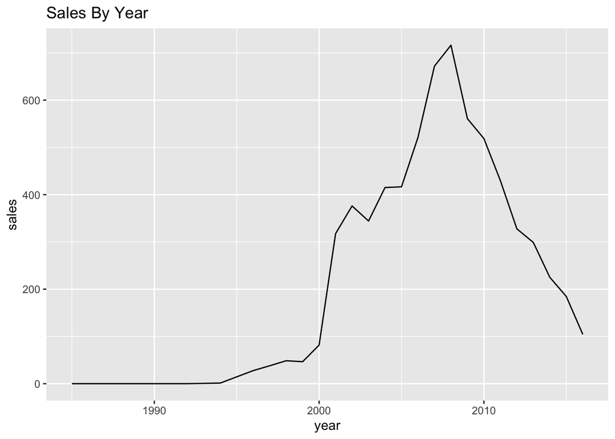

```r
SalesByYear <-
  Games_final %>%
  group_by(year) %>% #group by year to count sales by year
  summarise(total = sum(global_sales)) %>% #sum of the sales
  arrange((year))
SalesByYear %>%
  ggplot(aes(x = year, y = total)) +
  ggtitle("Sales By Year") +
  geom_line() +
  ylab("sales")
```

#### Then, after taking year into account, we think the platform for video games is crucial also. We choose to use histogram to display the sales on differernt platforms.

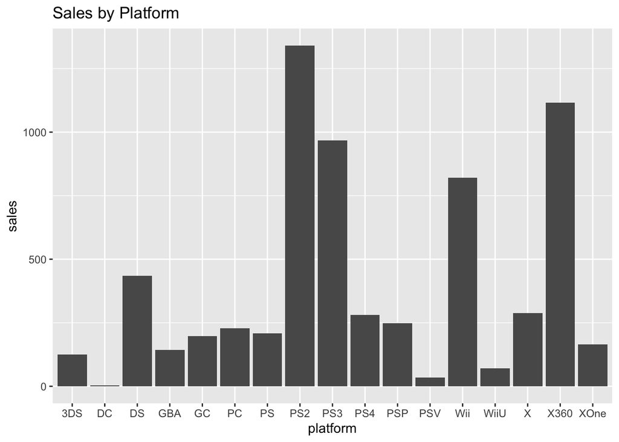

```r
SalesByPlatform <-
  Games_final %>%
  group_by(platform) %>% #group by platform to count platform
  summarise(total=sum(global_sales))
SalesByPlatform %>%
  ggplot(aes(x = platform)) +
  ggtitle("Sales by Platform") +
  geom_bar(aes(weight = total)) + #set up the y-axis as sales
  ylab("sales")
```

#### Obviously, we can see the video games on PS2,PS3,Wii and X360 has leading sales among all the platform. Actually, I own a X360, and I think it is a good platform to play, because it is connected, globally and well-designed platforms. Thus, as a customer, we prefer to choose a good platform first, and then to choose the games on the platform. Thus, the success of PS2,PS3,Wii,and X360 also brings the success of those videos games published on them.

#### Now, we are using the basic machine learning to help us find out which factors can heavily influence the sales of video games.

```r
Sales_platform_user_score <-
  party::ctree(
    global_sales ~ critic_score + user_score, #find the factors of global sales, and we are interested in user scores and critic scores.
    data=Games_final)
Games_final %>%
  mutate(probability=as.numeric(predict(Sales_platform_user_score)),
         likelihood =
           ifelse(global_sales,
                  probability,
                  1-probability)) %>%
  summarise(log_likelihood = sum(log(likelihood)))
```

```
## # A tibble: 1 x 1
##   log_likelihood
##            <dbl>
## 1         -3818.
```

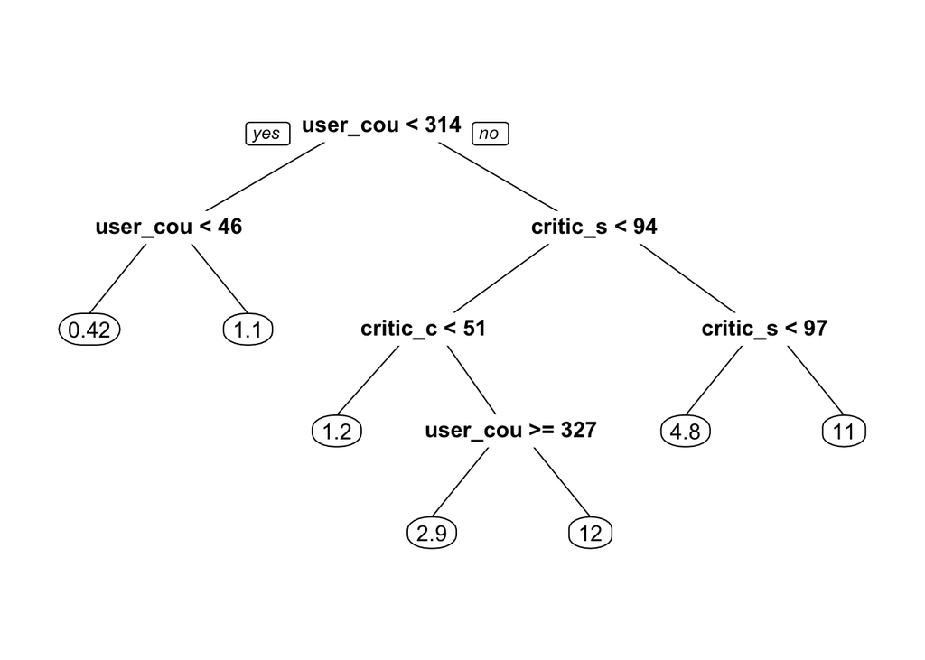

```r
DecisionTree <- rpart( global_sales ~ critic_score + critic_count + user_score + user_count, data = Games_final)
prp(DecisionTree)
```

#### In order to have a more comprehensive view, we decide to make a plot like this, including year, genre and ranking, which we believe to find some interesting result.

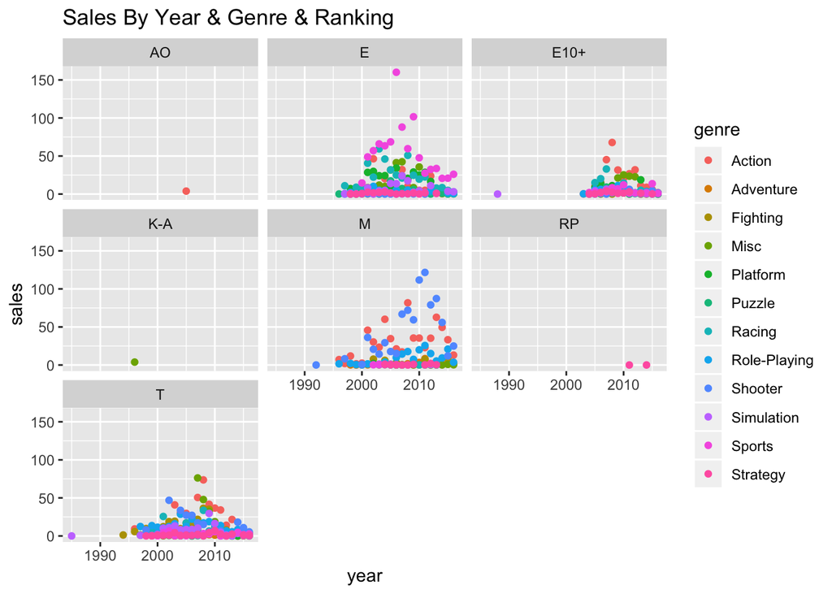

```r
Sales_By_Year_Genre_Ranking <-
  Games_final %>%
  group_by(genre,rating,year) %>%
  summarise(total = sum(global_sales))
Sales_By_Year_Genre_Ranking %>%
  ggplot(aes(x = year,y = total)) +
  geom_point(aes(color = genre)) +
  ggtitle("Sales By Year & Genre & Ranking") +
  facet_wrap(~rating) +
  ylab("sales")
```

#### This shows that if you want to do best selling video games, you may have to make it a E class, which requires a high-standard quality level. Other than that, we found that people were more likely to play sports games, like 2K,FIFA. Unluckily, even the E class, sports games in recent 5 years, the sales were far less than in 2008.

#### Lastly, we show the histogram of sales by top 7 developers. We want to find out which developer’s style is more popular, enabling us to have a good direction in designing our own games.

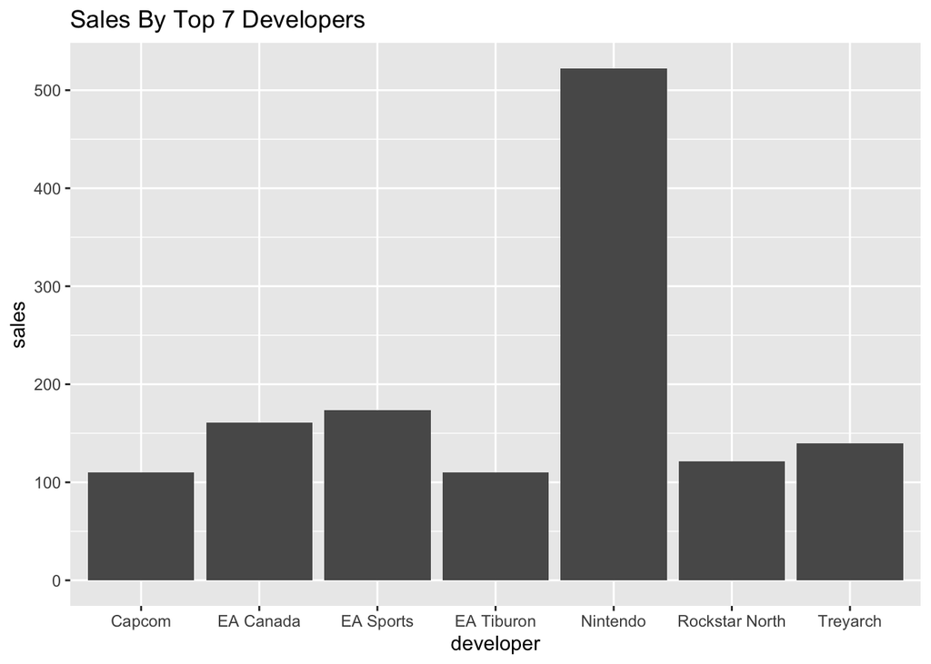

```r
SalesByDeveloper <-
  Games_final %>%
  group_by(developer) %>%
  summarise(total = sum(global_sales)) %>%
  arrange(desc(total)) %>%
  head(7)
SalesByDeveloper %>%
  ggplot(aes(x = developer)) +
  geom_bar(aes(weight = total)) +
  ggtitle("Sales By Top 7 Developers") +
  ylab("sales")
```

#### Unsurprisingly, the games developed by Nintendo were the most popular. Honestly, I play games from Nintedo since I was 10. Some games like Mario are still very popular now.